# Telecom Churn Modelling

[figure not shown]

```python
# importing libararies

# Warning
import warnings
warnings.filterwarnings("ignore")

# for Data
import pandas as pd
import numpy as np
import math

# Visualization
import matplotlib.pyplot as plt
import seaborn as sns
sns.set_style(style='whitegrid')
sns.set(font_scale=1.5);
%matplotlib inline


# Preprocessing
from sklearn.preprocessing import LabelEncoder
from sklearn.preprocessing import StandardScaler; std_scaler = StandardScaler()

# Splitting
from sklearn.model_selection import train_test_split


# Models
from sklearn.linear_model import LogisticRegression
from sklearn.ensemble import RandomForestClassifier as RandomForest
from sklearn.ensemble import AdaBoostClassifier
from xgboost import XGBClassifier
from lightgbm import LGBMClassifier


# Metrics
from sklearn.metrics import fbeta_score, accuracy_score, make_scorer, classification_report
from sklearn.metrics import confusion_matrix, roc_curve, roc_auc_score
from sklearn.model_selection import GridSearchCV
```

```python
# reading dataset
data = pd.read_csv('Telco-Customer-Churn.csv')
```

# 1. Exploratory Data Analysis (EDA)

#### A glance at the dataset

```python
data.head()
```

|  | customerID | gender | SeniorCitizen | Partner | Dependents | tenure | PhoneService | MultipleLines | InternetService | OnlineSecurity | ... | DeviceProtection | TechSupport | StreamingTV | StreamingMovies | Contract | PaperlessBilling | PaymentMethod | MonthlyCharges | TotalCharges | Churn |
| --- | --- | --- | --- | --- | --- | --- | --- | --- | --- | --- | --- | --- | --- | --- | --- | --- | --- | --- | --- | --- | --- |
| 0 | 7590-VHVEG | Female | 0 | Yes | No | 1 | No | No phone service | DSL | No | ... | No | No | No | No | Month-to-month | Yes | Electronic check | 29.85 | 29.85 | No |
| 1 | 5575-GNVDE | Male | 0 | No | No | 34 | Yes | No | DSL | Yes | ... | Yes | No | No | No | One year | No | Mailed check | 56.95 | 1889.5 | No |
| 2 | 3668-QPYBK | Male | 0 | No | No | 2 | Yes | No | DSL | Yes | ... | No | No | No | No | Month-to-month | Yes | Mailed check | 53.85 | 108.15 | Yes |
| 3 | 7795-CFOCW | Male | 0 | No | No | 45 | No | No phone service | DSL | Yes | ... | Yes | Yes | No | No | One year | No | Bank transfer (automatic) | 42.30 | 1840.75 | No |
| 4 | 9237-HQITU | Female | 0 | No | No | 2 | Yes | No | Fiber optic | No | ... | No | No | No | No | Month-to-month | Yes | Electronic check | 70.70 | 151.65 | Yes |

5 rows × 21 columns

#### Dataset Information

```python
# information about the dataset structure
data.info()
```

```
<class 'pandas.core.frame.DataFrame'>
RangeIndex: 7043 entries, 0 to 7042
Data columns (total 21 columns):
customerID          7043 non-null object
gender              7043 non-null object
SeniorCitizen       7043 non-null int64
Partner             7043 non-null object
Dependents          7043 non-null object
tenure              7043 non-null int64
PhoneService        7043 non-null object
MultipleLines       7043 non-null object
InternetService     7043 non-null object
OnlineSecurity      7043 non-null object
OnlineBackup        7043 non-null object
DeviceProtection    7043 non-null object
TechSupport         7043 non-null object
StreamingTV         7043 non-null object
StreamingMovies     7043 non-null object
Contract            7043 non-null object
PaperlessBilling    7043 non-null object
PaymentMethod       7043 non-null object
MonthlyCharges      7043 non-null float64
TotalCharges        7043 non-null object
Churn               7043 non-null object
dtypes: float64(1), int64(2), object(18)
memory usage: 1.1+ MB
```

#### Fixing `TotalCharges` datatype

```python
data['TotalCharges'] = data['TotalCharges'].convert_objects(convert_numeric=True)
data['TotalCharges'].dtype
```

```
dtype('float64')
```

#### Getting Statistical insights

```python
# Numerical features stats
data.describe().drop('SeniorCitizen', axis=1)
```

|  | tenure | MonthlyCharges | TotalCharges |
| --- | --- | --- | --- |
| count | 7043.000000 | 7043.000000 | 7032.000000 |
| mean | 32.371149 | 64.761692 | 2283.300441 |
| std | 24.559481 | 30.090047 | 2266.771362 |
| min | 0.000000 | 18.250000 | 18.800000 |
| 25% | 9.000000 | 35.500000 | 401.450000 |
| 50% | 29.000000 | 70.350000 | 1397.475000 |
| 75% | 55.000000 | 89.850000 | 3794.737500 |
| max | 72.000000 | 118.750000 | 8684.800000 |

`SeniorCitizen` feature is a binary categorical feature so looking at it's stats is nonesense.

```python
data.describe(include=['object'])
```

|  | customerID | gender | Partner | Dependents | PhoneService | MultipleLines | InternetService | OnlineSecurity | OnlineBackup | DeviceProtection | TechSupport | StreamingTV | StreamingMovies | Contract | PaperlessBilling | PaymentMethod | Churn |
| --- | --- | --- | --- | --- | --- | --- | --- | --- | --- | --- | --- | --- | --- | --- | --- | --- | --- |
| count | 7043 | 7043 | 7043 | 7043 | 7043 | 7043 | 7043 | 7043 | 7043 | 7043 | 7043 | 7043 | 7043 | 7043 | 7043 | 7043 | 7043 |
| unique | 7043 | 2 | 2 | 2 | 2 | 3 | 3 | 3 | 3 | 3 | 3 | 3 | 3 | 3 | 2 | 4 | 2 |
| top | 2197-OMWGI | Male | No | No | Yes | No | Fiber optic | No | No | No | No | No | No | Month-to-month | Yes | Electronic check | No |
| freq | 1 | 3555 | 3641 | 4933 | 6361 | 3390 | 3096 | 3498 | 3088 | 3095 | 3473 | 2810 | 2785 | 3875 | 4171 | 2365 | 5174 |

#### preparing dataa before visual data exoloration

in the `MultipleLines` feature a customer who has no phone service still has no multiple lines so I will replace the 'No Phone Service' values with just 'No' similarly, in `OnlineSecurity`, `OnlineBackup`, `DeviceProtection`, `TechSupport`,`StreamingTV`, `StreamingMovies` 'No internet servive' will be replaced by 'No'

```python
for dataset in [data]:
    dataset['MultipleLines'] = dataset['MultipleLines'].replace({'No phone service':'No'})
    dataset['OnlineSecurity'] = dataset['OnlineSecurity'].replace({'No internet service':'No'})
    dataset['DeviceProtection'] = dataset['DeviceProtection'].replace({'No internet service':'No'})
    dataset['TechSupport'] = dataset['TechSupport'].replace({'No internet service':'No'})
    dataset['StreamingTV'] = dataset['StreamingTV'].replace({'No internet service':'No'})
    dataset['OnlineBackup'] = dataset['OnlineBackup'].replace({'No internet service':'No'})
    dataset['StreamingMovies'] = dataset['StreamingMovies'].replace({'No internet service':'No'})

print ("Number of unique values in each column\n")
for col_name in data.columns:
 print(col_name,": " ,data[col_name].nunique())
```

```
Number of unique values in each column

customerID :  7043
gender :  2
SeniorCitizen :  2
Partner :  2
Dependents :  2
tenure :  73
PhoneService :  2
MultipleLines :  2
InternetService :  3
OnlineSecurity :  2
OnlineBackup :  2
DeviceProtection :  2
TechSupport :  2
StreamingTV :  2
StreamingMovies :  2
Contract :  3
PaperlessBilling :  2
PaymentMethod :  4
MonthlyCharges :  1585
TotalCharges :  6530
Churn :  2
```

# 2. Visual Data Analysis (VDA)

```
Text(0.5,1,'Number of customer churn')
```

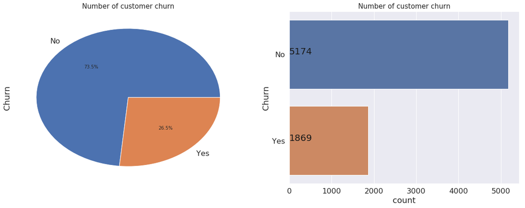

```python
# count of customers churn

fig, axes = plt.subplots(nrows=1, ncols=2, figsize=(20,7))
ax = data['Churn'].value_counts().plot(kind='pie',autopct='%.1f%%', ax=axes[0])
ax.set_title('Number of customer churn', fontsize=15)


ax = sns.countplot(y='Churn', data=data, ax=axes[1]);
for i,j in enumerate(data["Churn"].value_counts().values) :
    ax.text(.1,i,j,fontsize = 20,color = "k")

ax.set_title('Number of customer churn', fontsize=15)
```

###### It seems like the dataset is partially imbalanced

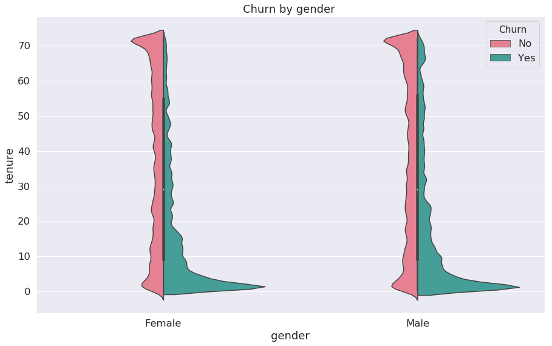

```python
ig, ax = plt.subplots(figsize=(15,9))
sns.violinplot(x="gender", y="tenure", hue='Churn', data=data, split=True, bw=0.05 , palette='husl', ax=ax)
plt.title('Churn by gender ')
plt.show()
```

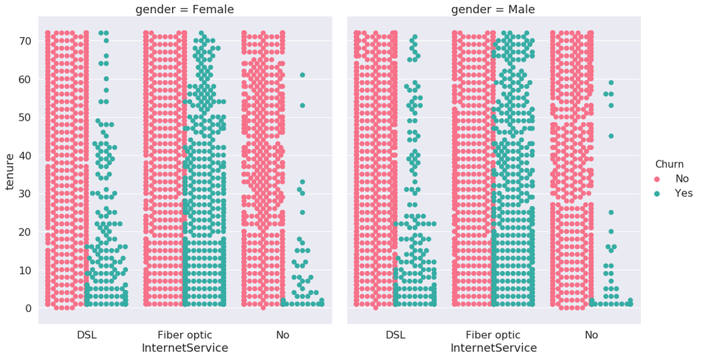

```python
g = sns.factorplot(x="InternetService", y="tenure", hue="Churn", col="gender", data=data, kind="swarm", dodge=True, palette='husl', size=8, aspect=.9, s=8)
```

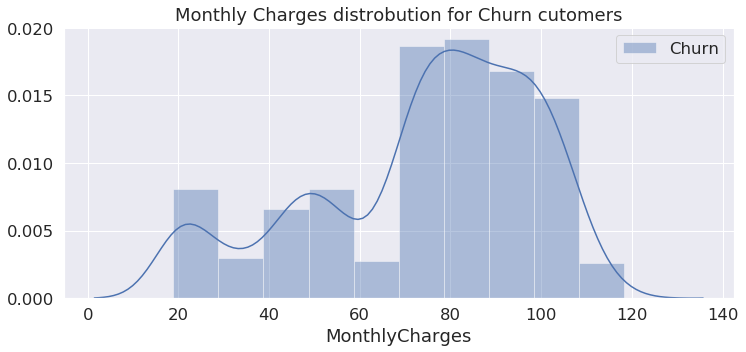

```python
fig, ax = plt.subplots(figsize=(12, 5))

ax = sns.distplot(data[data['Churn']=='Yes']['MonthlyCharges'],label='Churn', bins= 10, kde=True)
#ax = sns.distplot(data[data['Churn']=='No']['MonthlyCharges'],label='Not Churn', bins= 18, kde=False)

ax.legend()
ax.set_title('Monthly Charges distrobution for Churn cutomers')
plt.show()
```

##### Customers have higher probability to churn when monthly charges are high which agrees with my hypothesis, now the last part of my hypothesis is tht to show that Fiber Optic customers pay high monthly charges combared to other internet services which eventually leads to their churn.

```
Text(0.5,1,'Internet service vs. monthly charges')
```

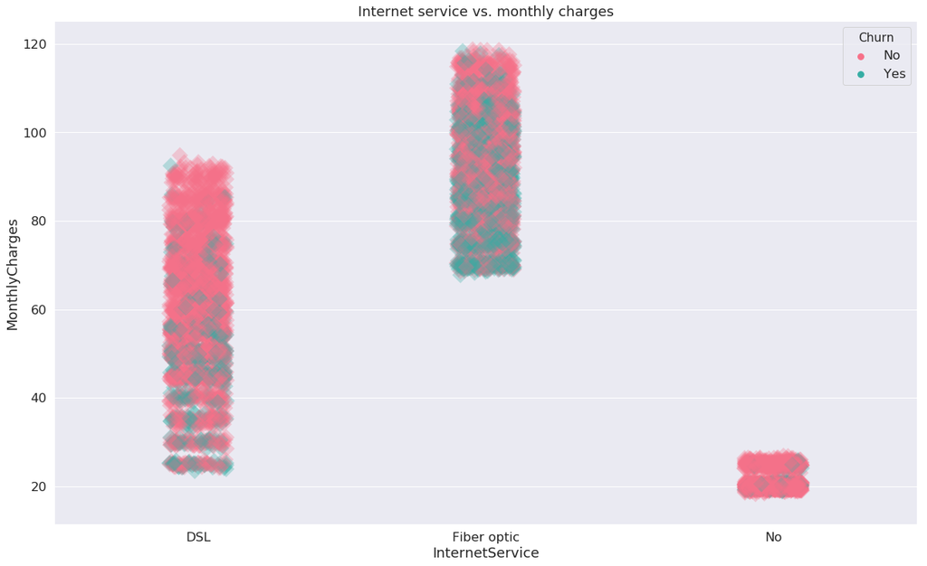

```python
fig, ax = plt.subplots(figsize=(20,12))
ax =  sns.stripplot('InternetService', 'MonthlyCharges', 'Churn', data=data,
                        palette="husl", size=15, marker="D",
                        edgecolor="red", alpha=.30)
ax.set_title('Internet service vs. monthly charges')
```

##### Now this confirms my hypithesis, as you see the Fiber optic internet service is the most expensixe one and customers who have high monthly charges have higher tendency to leave the company, this is why customers who subscribe to the Fiber optic service are more likely to leave the company although they have high quality and internet speed service.

###### This observation is very important for the company as they might target this customer segment and try to make offers to decrease the monthly charges on the fiber optics service or suggest them to use DSL for example if they can't afford the fiber optic service for so long.

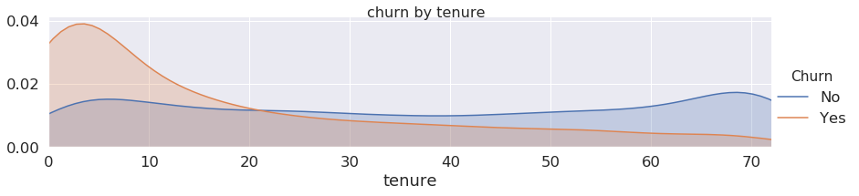

```python
FacetGrid = sns.FacetGrid(data, hue='Churn', aspect=4)
FacetGrid.map(sns.kdeplot, 'tenure', shade=True)
FacetGrid.set(xlim=(0, data['tenure'].max()))
FacetGrid.fig.suptitle('churn by tenure', fontsize=16)
FacetGrid.add_legend()
```

##### cusotomers tend to churn after the first few months of their subscribtion so, the company may need to target new customers with marketing campaign and offers.

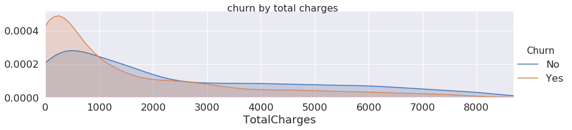

```python
FacetGrid = sns.FacetGrid(data, hue='Churn', aspect=4)
FacetGrid.map(sns.kdeplot, 'TotalCharges', shade=True)
FacetGrid.set(xlim=(0, data['TotalCharges'].max()))
FacetGrid.fig.suptitle('churn by total charges', fontsize=16)
FacetGrid.add_legend()
```

##### customers with low Total charges are more likely to churn.

```
Text(0.5,1,'Count customers by Payment Method')
```

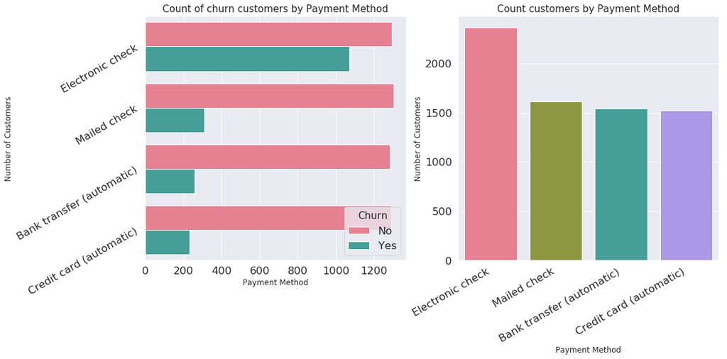

```python
fig, axes = plt.subplots(nrows=1, ncols=2, figsize=(16, 7))

# count of churn customers by payment method
ax = sns.countplot(y='PaymentMethod', hue='Churn', data=data, palette="husl", ax=axes[0]);

ax.set_yticklabels(ax.get_yticklabels(), rotation=30, ha="right")
ax.set_xlabel('Payment Method', fontsize = 12)
ax.set_ylabel('Number of Customers', fontsize = 12)

ax.set_title('Count of churn customers by Payment Method', fontsize=15)





# count of customers by payment method
ax = sns.countplot(x='PaymentMethod', data=data, palette="husl", ax=axes[1]);

ax.set_xticklabels(ax.get_xticklabels(), rotation=30, ha="right")
ax.set_xlabel('Payment Method', fontsize = 12)
ax.set_ylabel('Number of Customers', fontsize = 12)

ax.set_title('Count customers by Payment Method', fontsize=15)
```

##### It's obvious that customers who pay by Electronic check have a high tendency to check

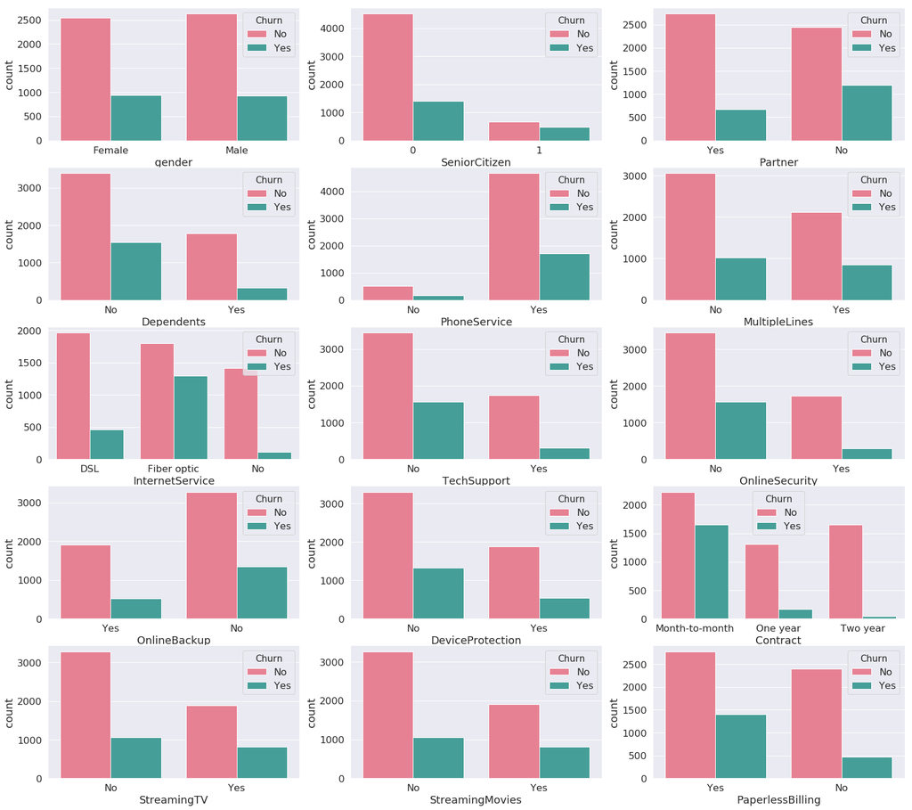

```python
fig, axes = plt.subplots(nrows=5, ncols=3, figsize=(26, 24))

plot = ['gender', 'SeniorCitizen', 'Partner', 'Dependents',
        'PhoneService', 'MultipleLines', 'InternetService', 'TechSupport',
       'OnlineSecurity', 'OnlineBackup', 'DeviceProtection', 'Contract',
       'StreamingTV', 'StreamingMovies', 'PaperlessBilling']
index = 0
for i in range(5):
    for j in range(3):

        ax = sns.countplot(x=plot[index], hue='Churn', data=data, palette="husl", ax=axes[i,j]);
        index+=1
```

- **gender**: Females have a very small tendency to churn other than men, I guess there is no much impact for the gender on churn.
- **SeniorCitizen**: Seniors are more likely to churn.
- **Partner**: customers who have no partners are more likely to churn.
- **Dependents**: having dependents makes customers less likely to churn.
- **MultipleLines**: having multiple lines makes customers more likely to churn.
- **Contract**: Month_to_Month contracts are more likely to churn.
- **PaperlessBilling**: A lot of customers who have paperless billing have churned so, the company need to investigate it's system searching for the problem.

# 3. Data Preprocessing

#### Removing `customerID` as it doesn't contribute to the prediction of churn.

```python
df = data.copy()
```

```python
df = df.drop('customerID', axis=1)
```

##### Getting dummy variables for categorical columns of mare than two values

```python
# Getting dummy variables for these columns
# using drop_first=True in order to avoid the dummy variables trap

df = pd.get_dummies(data = df,columns = ['InternetService', 'Contract', 'PaymentMethod'], drop_first=True )
```

#### Encoding categorical variables

```python
enc = LabelEncoder()
df = df.apply(enc.fit_transform)
df.head()
```

|  | gender | SeniorCitizen | Partner | Dependents | tenure | PhoneService | MultipleLines | OnlineSecurity | OnlineBackup | DeviceProtection | ... | MonthlyCharges | TotalCharges | Churn | InternetService_Fiber optic | InternetService_No | Contract_One year | Contract_Two year | PaymentMethod_Credit card (automatic) | PaymentMethod_Electronic check | PaymentMethod_Mailed check |
| --- | --- | --- | --- | --- | --- | --- | --- | --- | --- | --- | --- | --- | --- | --- | --- | --- | --- | --- | --- | --- | --- |
| 0 | 0 | 0 | 1 | 0 | 1 | 0 | 0 | 0 | 1 | 0 | ... | 142 | 74 | 0 | 0 | 0 | 0 | 0 | 0 | 1 | 0 |
| 1 | 1 | 0 | 0 | 0 | 34 | 1 | 0 | 1 | 0 | 1 | ... | 498 | 3624 | 0 | 0 | 0 | 1 | 0 | 0 | 0 | 1 |
| 2 | 1 | 0 | 0 | 0 | 2 | 1 | 0 | 1 | 1 | 0 | ... | 436 | 536 | 1 | 0 | 0 | 0 | 0 | 0 | 0 | 1 |
| 3 | 1 | 0 | 0 | 0 | 45 | 0 | 0 | 1 | 0 | 1 | ... | 266 | 3570 | 0 | 0 | 0 | 1 | 0 | 0 | 0 | 0 |
| 4 | 0 | 0 | 0 | 0 | 2 | 1 | 0 | 0 | 0 | 0 | ... | 729 | 674 | 1 | 1 | 0 | 0 | 0 | 0 | 1 | 0 |

5 rows × 24 columns

# 4. Splitting dataset and scaling it

```python
X = df.drop('Churn', axis=1)
X_columns = X.columns
y= df['Churn']
```

##### Scaling features

```python
X = std_scaler.fit_transform(X)
```

##### splitting dataset into training and testing

```python
X_train, X_test, y_train, y_test = train_test_split(X,y, test_size=0.25,random_state=42)
```

# ==========================================================================================================

# 5. Building Benchmark model (Logistic regression)

```python
log_reg = LogisticRegression()
log_reg.fit(X_train, y_train)
y_pred = log_reg.predict(X_test)
acc_log_reg = log_reg.score(X_test, y_test)*100
print("{:.2f}".format(acc_log_reg))
```

```
80.58
```

##### Evaluating our benchmark model

##### Logistic Regression Classification report

```python
print (classification_report(y_test, y_pred))
```

```
             precision    recall  f1-score   support

          0       0.83      0.91      0.87      1282
          1       0.69      0.52      0.59       479

avg / total       0.80      0.81      0.80      1761
```

#### Confusion matrix

```
<function matplotlib.pyplot.show(*args, **kw)>
```

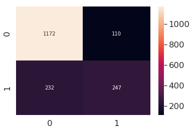

```python
lr_conf = confusion_matrix(y_test, y_pred)
sns.heatmap(lr_conf, annot=True, fmt="d")
plt.show
```

##### ROC Curve/Score

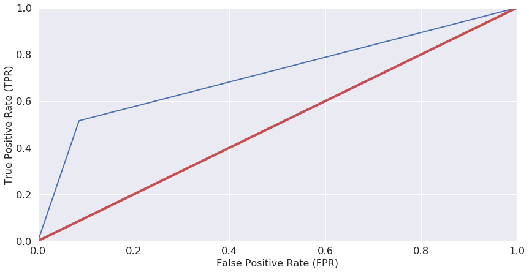

```python
false_positive_rate, true_positive_rate, threshold = roc_curve(y_test, y_pred)

# plotting them against each other
def plot_roc_curve(false_positive_rate, true_positive_rate, label=None):
    plt.plot(false_positive_rate, true_positive_rate, linewidth=2, label=label)
    plt.plot([0, 1], [0, 1], 'r', linewidth=4)
    plt.axis([0, 1, 0, 1])
    plt.xlabel('False Positive Rate (FPR)', fontsize=16)
    plt.ylabel('True Positive Rate (TPR)', fontsize=16)

plt.figure(figsize=(14, 7))
plot_roc_curve(false_positive_rate, true_positive_rate)
plt.show()
```

```python
lr_auc = roc_auc_score(y_test, y_pred)
print("Roc score: ", round(lr_auc,2)*100, "%")
```

```
Roc score:  71.0 %
```

# 6. Bulding And Evaluating Models

```python
#Random Forest
rf = RandomForest(random_state=42)
rf.fit(X_train, y_train)
y_pred_rf = rf.predict(X_test)
acc_rf = rf.score(X_test, y_test) * 100
print("{:.2f}".format(acc_rf))
```

```
77.80
```

```
<function matplotlib.pyplot.show(*args, **kw)>
```

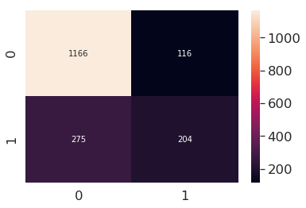

```python
RF_conf = confusion_matrix(y_test, y_pred_rf)
sns.heatmap(RF_conf, annot=True, fmt="d")
plt.show
```

```python
# Ada Boost
AdaBoost = AdaBoostClassifier(random_state=42)
AdaBoost.fit(X_train, y_train)
y_pred = AdaBoost.predict(X_test)
acc_AdaBoost = AdaBoost.score(X_test, y_test) * 100
print("{:.2f}".format(acc_AdaBoost))
```

```
80.12
```

```
<function matplotlib.pyplot.show(*args, **kw)>
```

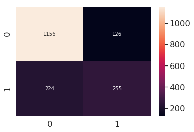

```python
Ada_conf = confusion_matrix(y_test, y_pred)
sns.heatmap(Ada_conf, annot=True, fmt="d")
plt.show
```

```python
# LGBM Classifier
lgbm = LGBMClassifier(random_state=42)
lgbm.fit(X_train, y_train)
y_pred = lgbm.predict(X_test)
acc_lgbm = lgbm.score(X_test, y_test) * 100
print("{:.2f}".format(acc_lgbm))
```

```
79.61
```

```
<function matplotlib.pyplot.show(*args, **kw)>
```

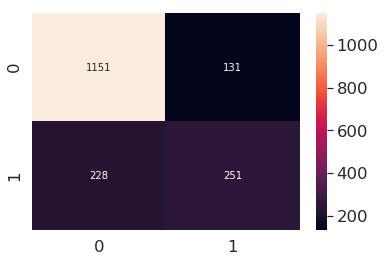

```python
LGBM_conf = confusion_matrix(y_test, y_pred)
sns.heatmap(LGBM_conf, annot=True, fmt="d")
plt.show
```

```python
# XGBoost
xg = XGBClassifier(random_state=42)
xg.fit(X_train, y_train)
y_pred = xg.predict(X_test)
acc_xg = xg.score(X_test, y_test) * 100
print("{:.2f}".format(acc_xg))
```

```
80.07
```

```
<function matplotlib.pyplot.show(*args, **kw)>
```

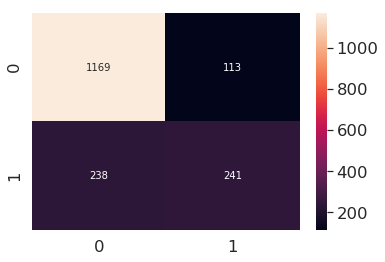

```python
XG_conf = confusion_matrix(y_test, y_pred)
sns.heatmap(XG_conf, annot=True, fmt="d")
plt.show
```

# 6. Validating Model

#### Choosing the best model

The 2 common error types in Churn Prediction:

> **Type I Error — False Negative: Failing to identify a customer who has a high propensity to unsubscribe.**

From a business perspective, this is the **least desirable error** as the customer is very likely to quit/cancel/abandon the business, thus adversely affecting its revenue.

> **Type II Error — False Positive: Classifying a good, satisfied customer as one likely to Churn.**

From a business perspective, this is **acceptable** as it does not impact revenue.

Any Predictive Algorithm going into Production will have to be **the one with the least Type I error.**

Type I Error in our confusion matrix is when the customer is going to churn (1) but the model have predicted that he/she is not going to churn(0) so Type I Error is the **left bottom** cell in our confusion matrix.

### Ada Boost has the least Type I Error of 224 so it will be our final model.

Ada Boost has beaten our benchmark model which have Type I Error of 232.

# 7. Optimization - Hyper Parameter tuning

```python
clf = AdaBoostClassifier(random_state=42)

param_grid = {"n_estimators": [50, 100, 300, 500],\
              "learning_rate" : [1, 0.0001, 0.5]}

grid_obj = GridSearchCV(clf, param_grid=param_grid, cv=10)


grid_fit = grid_obj.fit(X_train, y_train)

print("Best parameter: ", grid_obj.best_params_)

# Get the estimator/ clf
best_clf = grid_fit.best_estimator_

grid_y_pred = best_clf.predict(X_test)

print("Optimal accuracy score on the testing data: {:.2f}".format(accuracy_score(y_test, grid_y_pred)*100))
```

```
Best parameter:  {'learning_rate': 1, 'n_estimators': 50}
Optimal accuracy score on the testing data: 80.12
```

##### Plotting features importance

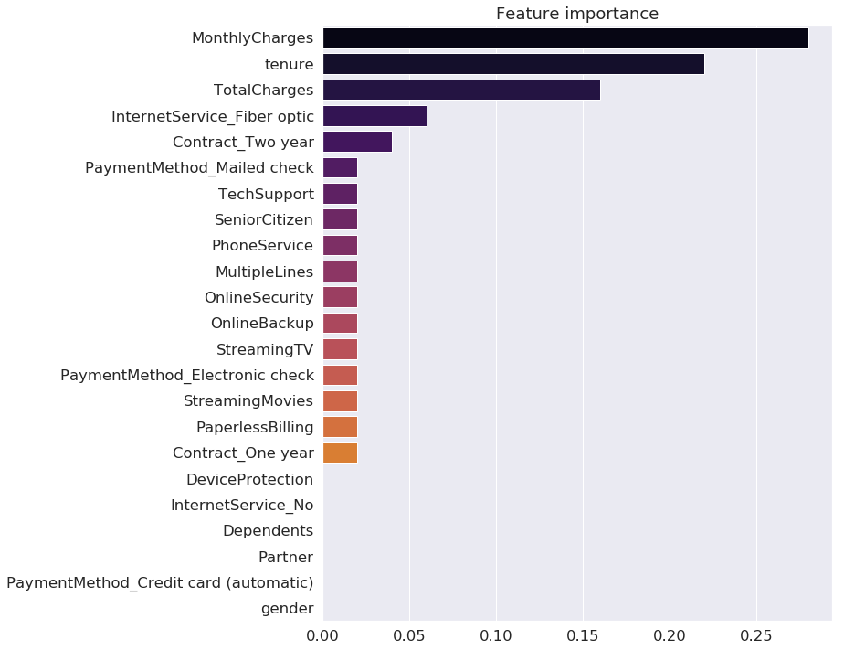

```python
plt.figure(figsize=(10,12))
plt.title("Feature importance")
imp = pd.Series(data=best_clf.feature_importances_, index=X_columns).sort_values(ascending=False)
ax = sns.barplot(y=imp.index, x=imp.values, palette="inferno", orient='h')
```

It seems like the default parameters achieve the highest performance.

##### Ada Boost Classification report

```python
print (classification_report(y_test, grid_y_pred))
```

```
             precision    recall  f1-score   support

          0       0.84      0.90      0.87      1282
          1       0.67      0.53      0.59       479

avg / total       0.79      0.80      0.79      1761
```

##### Confusion matrix

```
<function matplotlib.pyplot.show(*args, **kw)>
```

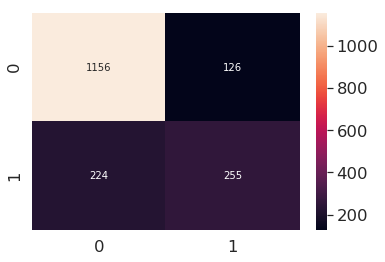

```python
Grid_conf = confusion_matrix(y_test, grid_y_pred)
sns.heatmap(Grid_conf, annot=True, fmt="d")
plt.show
```

##### ROC Curve/Score

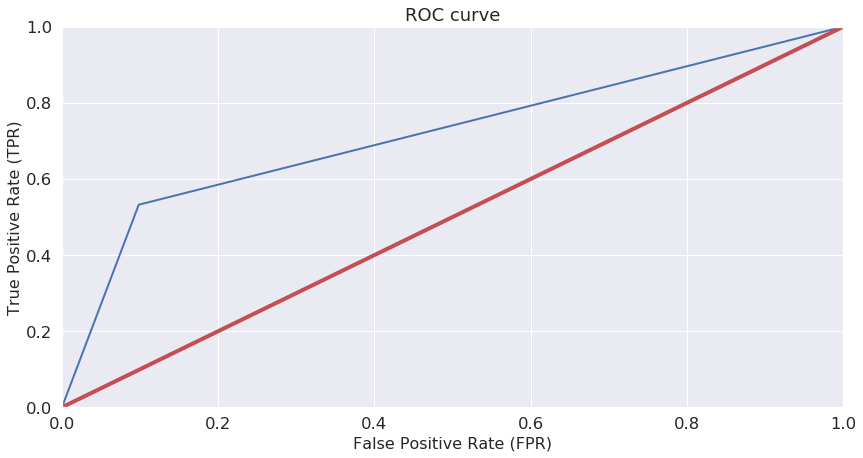

```python
false_positive_rate, true_positive_rate, threshold = roc_curve(y_test, grid_y_pred)

# plotting them against each other
def plot_roc_curve(false_positive_rate, true_positive_rate, label=None):
    plt.plot(false_positive_rate, true_positive_rate, linewidth=2, label=label)
    plt.plot([0, 1], [0, 1], 'r', linewidth=4)
    plt.axis([0, 1, 0, 1])
    plt.xlabel('False Positive Rate (FPR)', fontsize=16)
    plt.ylabel('True Positive Rate (TPR)', fontsize=16)

plt.figure(figsize=(14, 7))
plot_roc_curve(false_positive_rate, true_positive_rate)
plt.title("ROC curve")
plt.show()
```

```python
grid_auc = roc_auc_score(y_test, grid_y_pred)
print("Roc score: {:.2f}".format((grid_auc)*100), "%")
```

```
Roc score: 71.70 %
```